# Estadística descriptiva con R

Ejemplo de solución ejercicio prático n°1

## Enunciado

Sabemos que uno de los uso de los modelos estadísticos es describir o caracterizar un conjunto de datos, lo que aprendimos en la enseñanza secundaria y en cursos anteriores con el nombre de estadística descriptiva. Son muchas las herramientas, pero es importante saber usar la que es adecuada para lo que se quiere describir.

En este contexto trabajaremos con una selección de datos públicos recopilados por la encuesta CASEN 2017 en la Región Metropolitana (RM). La Encuesta CASEN es un estudio que mide la situación socioeconómica de los hogares en el país. Se realiza periódicamente y permite obtener datos sobre pobreza, ingresos, acceso a servicios básicos, educación, salud, y más, lo que ayuda a diseñar políticas públicas y programas sociales. La siguiente tabla detalla las variables seleccionadas:

Descripción de los datos

| Variable | Descripción |
| --- | --- |
| folio | Identificador del hogar. |
| o | Número de orden de la persona dentro del hogar. |
| id.vivienda | Identificación de la vivienda. |
| hogar | Identificación del hogar en la vivienda. |
| region | Nombre de la región de Chile donde se ubica la vivienda (solo “Región Metropolitana de Santiago” en esta selección de datos). |
| provincia | Nombre de la provincia donde se ubica la vivienda (solo las 6 provincias de la RM en esta selección de datos). |
| comuna | Nombre de la comuna donde se ubica la vivienda (solo las 52 comunas de la RM en esta selección de datos). |
| ing.comuna | Posición en el ranking histórico del ingreso de la comuna (ascendente). |
| zona | Área geográfica (“Rural”, “Urbano”). |
| sexo | Sexo de la persona encuestada (“Hombre”, “Mujer”). |
| edad | Edad de la persona encuestada. |
| ecivil | Estado civil de la persona encuestada (8 posibles valores). |
| ch1 | Situación ocupacional de la persona encuestada (4 posibles valores). |
| ytot | Ingreso total (en pesos) |

Para este ejercicio se pide realizar las siguientes actividades:

1. Formar un equipo de 3 personas que cuente con al menos un computador con el entorno R instalado.
2. Obtener el archivo de datos desde la carpeta compartida para este ejercicio.
3. Considerar la pregunta asignada a su equipo. Discutir y consensuar qué medidas estadísticas (media, mediana, moda, etc.) y qué forma gráfica ayudaría a responder la pregunta asignada.
4. Construir un script en R que produzca los estadísticos y el gráfico seleccionado.
5. Documentar en el script el objetivo de cada estadístico, una descripción de lo que se ve en el gráfico y la respuesta a la pregunta planteada.

Comencemos Incluyendo los paquetes que usaremos en este script.

```r
library(dplyr)
library(ggpubr)
library(psych)
```

A continuación obtengamos los datos.

```r
src_dir <- "~/Downloads"
src_basename <- "EP01 Datos Casen 2017.csv"
src_file <- file.path(src_dir, src_basename)

datos <- read.csv2(src_file, stringsAsFactors = TRUE)
```

Vamos a reescalar la variable ingreso (`ytot`) de $1 a $1.000 para mayor claridad.

```r
datos[["ytot"]] <- datos[["ytot"]] / 1000
```

## Análisis de frecuencias

¿Se encuestaron más o menos la misma cantidad de gente en cada provincia de la RM?

Para responder a esta pregunta, debemos revisar las **frecuencias** y/o **proporciones** de personas encuestadas por provincia. Si estas se parecen, entonces la respuesta sería positiva, y en caso contrario, negativa.

```r
tabla_provincias <- as.data.frame(table(datos[["provincia"]]))
colnames(tabla_provincias) <- c("Provincia", "Frecuencia")
prop_provincias <- tabla_provincias[["Frecuencia"]] / sum(tabla_provincias[["Frecuencia"]]) * 100
tabla_provincias[["Prop."]] <- round(prop_provincias, 1)

cat("Encuestados por provincia:\n")
print(tabla_provincias)
```

```
Encuestados por provincia:
   Provincia Frecuencia Prop.
1  Chacabuco       1274   4.5
2 Cordillera       1766   6.3
3      Maipo       1718   6.1
4  Melipilla        977   3.5
5   Santiago      21179  75.5
6  Talagante       1148   4.1
```

Para reportar visualmente frecuencias o proporciones, podríamos utilizar un gráfico de torta. Pero si la intención del gráfico es **comparar o contrastar** estas frecuencias o proporciones, es más adecuado usar un **gráfico de barras**. Generemos este gráfico para las frecuencias:

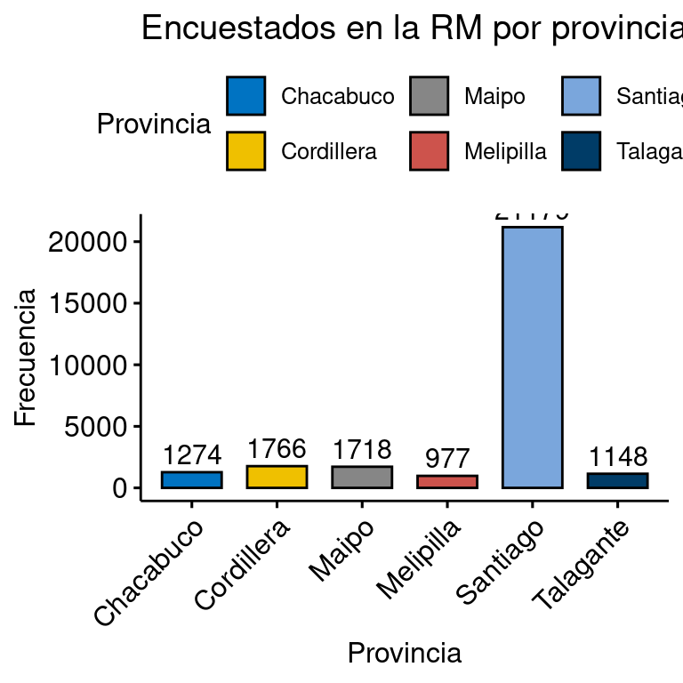

```r
# Construir gráfico de barras.
g_barra1 <- ggbarplot(tabla_provincias, x = "Provincia", y = "Frecuencia",
                      label = TRUE, lab.pos = "out", lab.col = "black",
                      fill = "Provincia", palette = "jco",
                      title = "Encuestados en la RM por provincia"
                     )
g_barra1 <- g_barra1 + rotate_x_text(angle = 45)
print(g_barra1)
```

En el gráfico podemos ver con claridad que la cantidad de personas encuestadas es mucho mayor en la provincia de Santiago. La tabla de encuestados por provincia nos informa que esta provincia representa más del 75% del total. Escribamos la conclusión

La encuesta CASEN 2017no fue aplicada a la misma cantidad de gente en cada provincia de la Región Metropolitana. La provincia de Santiago concentra la mayoría de las encuestras (3/4 partes). Las otras provincias representan entre 3,5% y 6,3%.

## Análisis de una variable númerica

¿Cómo podemos describir el ingreso de las chilenas y los chilenos de la RM?

Para responder a esta pregunta, primero debemos decir que *el ingreso*, medidos en miles de pesos en nuestros datos, puede considerarse como una variable continua que es redondeada por conveniencia. Por ejemplo, aunque una persona deba recibir $$372.313{,}2345\overline{6}$ de comisión por las ventas que hizo en el mes, es probable que su empleadora le pague $$372.313$.

Tenemos varias alternativas de gráficos para representar una variable continua. Por ejemplo, podríamos usar un **diagrama de cajas**, un diagrama de puntos, un diagrama de densidad o un **histograma**. Esta última es probablemente la alternativa más usada para **explorar** la forma en que se distribuyen los. Generemos estos gráficos con los datos de ingreso, marcando la media en cada uno de ellos.

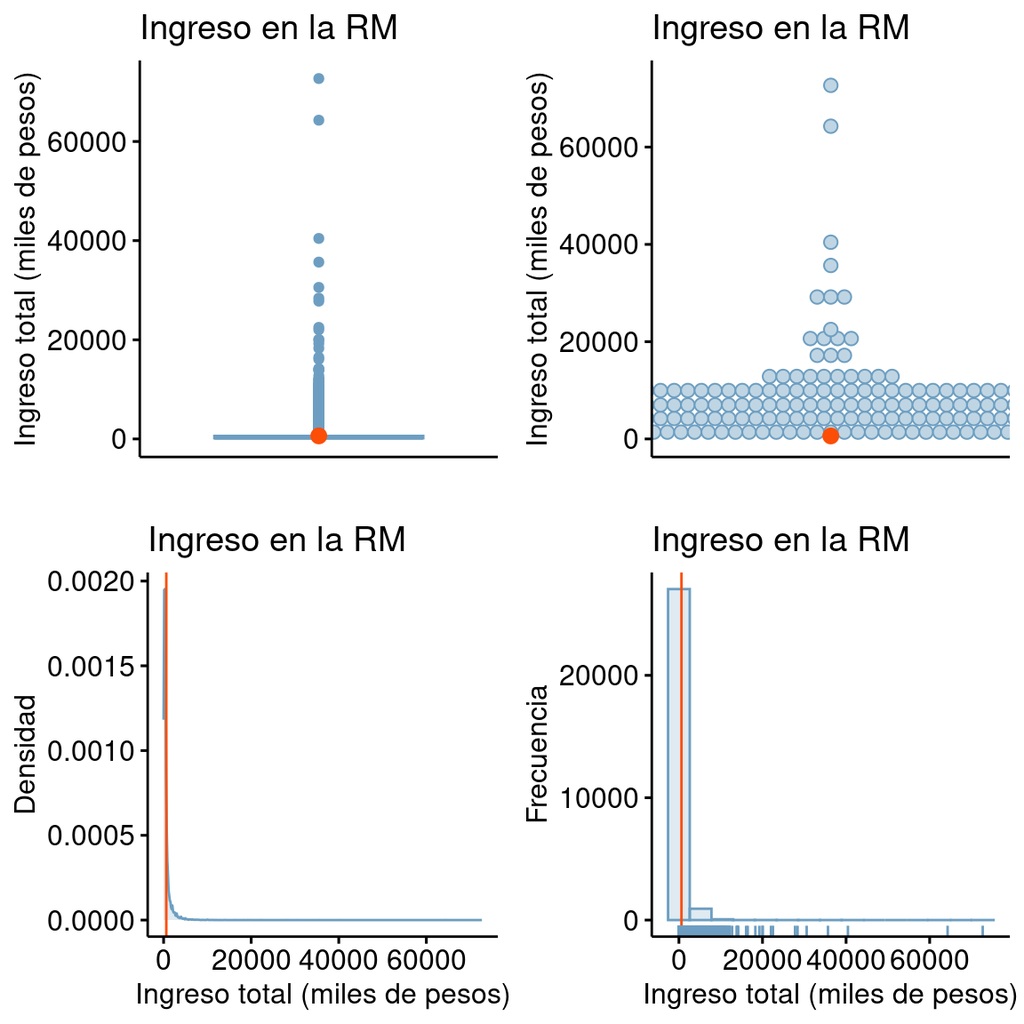

```r
# Diagrama de cajas
g_boxplot2 <- ggboxplot(datos, x = NULL, y = "ytot",
                        color = "#6D9EC1", fill = "#BFD5E3",
                        add = "mean", add.params = list(color = "#FC4E07"),
                        title = "Ingreso en la RM",
                        xlab = " ", ylab = "Ingreso total (miles de pesos)")
g_boxplot2 <- g_boxplot2 + rremove("x.text")
g_boxplot2 <- g_boxplot2 + rremove("x.ticks")

# Diagrama de puntos (1 punto = 2.800 observaciones)
g_puntos2 <- ggdotplot(datos, y = "ytot", binwidth = 2800,
                       color = "#6D9EC1", fill = "#BFD5E3",
                       add = "mean", add.params = list(color = "#FC4E07"),
                       title = "Ingreso en la RM",
                       xlab = " ", ylab = "Ingreso total (miles de pesos)")
g_puntos2 <- g_puntos2 + rremove("x.text")
g_puntos2 <- g_puntos2 + rremove("x.ticks")

# Diagrama de densidad
g_densi2 <- ggdensity(datos, x = "ytot",
                      color = "#6D9EC1", fill = "#BFD5E3",
                      add = "mean", add.params = list(color = "#FC4E07"),
                      title = "Ingreso en la RM",
                      xlab = "Ingreso total (miles de pesos)", ylab = "Densidad")

# Histograma
g_hist2 <- gghistogram(datos, x = "ytot", bins = 15,
                       color = "#6D9EC1", fill = "#BFD5E3",
                       add = "mean", add.params = list(color = "#FC4E07"), rug = TRUE,
                       title = "Ingreso en la RM",
                       xlab = "Ingreso total (miles de pesos)", ylab = "Frecuencia")

# Juntamos los gráficos
g2 <- ggarrange(g_boxplot2, g_puntos2, g_densi2, g_hist2, ncol = 2, nrow = 2)
print(g2)
```

Nota: Se han omitido los mensajes de *warning* que produce este código para no complicar el ejemplo. Estos se deben a que las funciones del paquete `ggpubr` siguen usando algunas funciones *deprecadas* en el paquete `ggplot2`.

Los gráficos nos muestran que la variable ingreso presenta una distribución muy asimétrica con valores atípicos (*outliers*) muy altos. Pero debemos observar que pareciera haber muchas observaciones alrededor del valor cero. Esto nos debería hacer dudar de que nuestros gráficos están correctos. Miremos un poco los datos:

```r
cat("Ingreso promedio por situación ocupacional:\n")
print(datos |> group_by(ch1) |> summarise(ingreso_medio = mean(ytot), n = n()))
```

```
Ingreso promedio por situación ocupacional:
# A tibble: 4 × 3
  ch1                                             ingreso_medio     n
  <fct>                                                   <dbl> <int>
1 Asalariado                                              801.  14575
2 Familiar no Remunerado/ Inactivos y Desocupados         251.   7252
3 Menores de 12 años                                       26.5  1489
4 Patrón o empleador/ Trabajador Cuenta Propia            783.   4746
```

Evidentemente estamos cometiendo un error al considerar todos los datos, pues en las encuestas existe un número importante de menores de edad, que uno esperaría no tuvieran ingresos. Quitemos estos datos de nuestros gráficos.

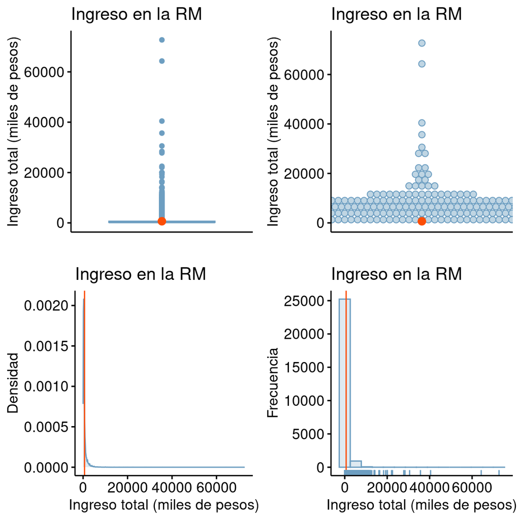

```r
datos_2 <- datos |> filter(edad >= 18)

# Diagrama de cajas
g_boxplot2 <- ggboxplot(datos_2, x = NULL, y = "ytot",
                        color = "#6D9EC1", fill = "#BFD5E3",
                        add = "mean", add.params = list(color = "#FC4E07"),
                        title = "Ingreso en la RM",
                        xlab = " ", ylab = "Ingreso total (miles de pesos)")
g_boxplot2 <- g_boxplot2 + rremove("x.text")
g_boxplot2 <- g_boxplot2 + rremove("x.ticks")

# Diagrama de puntos (1 punto = 2.600 observaciones)
g_puntos2 <- ggdotplot(datos_2, y = "ytot", binwidth = 2600,
                       color = "#6D9EC1", fill = "#BFD5E3",
                       add = "mean", add.params = list(color = "#FC4E07"),
                       title = "Ingreso en la RM",
                       xlab = " ", ylab = "Ingreso total (miles de pesos)")
g_puntos2 <- g_puntos2 + rremove("x.text")
g_puntos2 <- g_puntos2 + rremove("x.ticks")

# Diagrama de densidad
g_densi2 <- ggdensity(datos_2, x = "ytot",
                      color = "#6D9EC1", fill = "#BFD5E3",
                      add = "mean", add.params = list(color = "#FC4E07"),
                      title = "Ingreso en la RM",
                      xlab = "Ingreso total (miles de pesos)", ylab = "Densidad")

# Histograma
g_hist2 <- gghistogram(datos_2, x = "ytot", bins = 15,
                       color = "#6D9EC1", fill = "#BFD5E3",
                       add = "mean", add.params = list(color = "#FC4E07"), rug = TRUE,
                       title = "Ingreso en la RM",
                       xlab = "Ingreso total (miles de pesos)", ylab = "Frecuencia")

# Juntamos los gráficos
g2 <- ggarrange(g_boxplot2, g_puntos2, g_densi2, g_hist2, ncol = 2, nrow = 2)
print(g2)
```

¡Ah! No parece haber un cambio importante en los gráficos que siguen indicando que el ingreso en Chile se distribuye muy asimétricamente, con uno pocas observaciones con valores muy altos. Esto hace que las medidas, como la media, se **distorcionen**, por lo que es mejor usar otras medidas de tendencia central **más robustas**, tales como la mediana, el rango intercuartil o la media truncada (en inglés, *trimmed mean*). Veamos estas estadísticas.

```r
cat("Estadísticas del ingreso de mayores de edad en Chile:\n")
describe(datos_2[["ytot"]], skew = FALSE, IQR = TRUE, quant = c(0.25, 0.75, 0.9))
```

```
Estadísticas del ingreso de mayores de edad en Chile:
   vars     n   mean      sd median  min      max    range   se IQR Q0.25 Q0.75
X1    1 26237 655.44 1250.33 367.37 0.08 72691.66 72691.58 7.72 450   200   650
     Q0.9
X1 1400.2
```

Podemos ver que, mientras el ingreso medio de los mayores de edad de la RM es de aproximadamente $655 mil, la mitad de los encuestados (i.e. la mediana) consigue menos de $368 mil, 3/4 partes menos de $650 mil, y el 90% de los encuestados consigue menos de $1 millón 400 mil.

Mejoremos la vista que tenemos de los gráficos con estos datos.

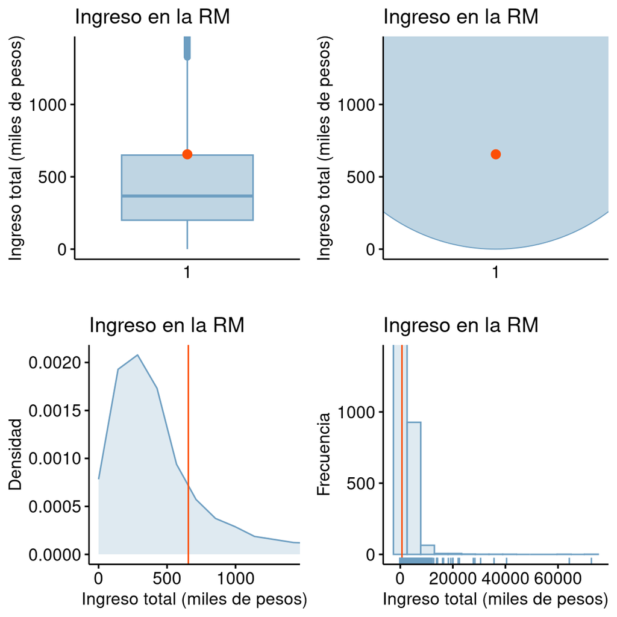

```r
# Hacemos una especie de 'zoom' al 90% inferior de las observaciones
g_boxplot2 <- ggpar(g_boxplot2, ylim = c(0, 1400))
g_puntos2 <- ggpar(g_puntos2, ylim = c(0, 1400))
g_densi2 <- ggpar(g_densi2, xlim = c(0, 1400))
g_hist2 <- ggpar(g_hist2, ylim = c(0, 1400))

# Juntamos los gráficos
g2 <- ggarrange(g_boxplot2, g_puntos2, g_densi2, g_hist2, ncol = 2, nrow = 2)
print(g2)
```

Y actualicemos las estadísticas.

```r
datos_2 <- datos_2 |> filter(ytot <= 1400) |> droplevels()

cat("Estadísticas del 90% inferior del ingreso de mayores de edad en Chile:\n")
describe(datos_2[["ytot"]], skew = FALSE, IQR = TRUE, quant = c(0.25, 0.75))
```

```
Estadísticas del 90% inferior del ingreso de mayores de edad en Chile:
   vars     n   mean     sd median  min  max   range   se    IQR Q0.25  Q0.75
X1    1 23613 395.97 293.75 331.02 0.08 1400 1399.92 1.91 336.63   180 516.63
```

Estamos en condiciones de concluir.

Los ingresos en Chile (en el año 2017) se distribuyen con una fuerte asimetría positiva. Así, la mayoría de la población tiene ingresos bajos (75% de la población obtiene menos de $650 mil y el 90% menos de $1 millón 400 mil), mientras que un grupo minoritario obtiene ingresos mucho mayores.

## Análisis de una variable númerica en dos grupos distintos

¿Tienen hombres y mujeres ingresos similares?

En este caso podemos usar los mismos gráficos que en el ejemplo anterior, pero mostrando cada grupo por separado. Para esto podemos usar la variable categórica (o **factor**, en jerga estadística) `sexo` para, por ejemplo, asignar el color del gráfico. Del ejercicio anterior recatamos que el diagrama de cajas y el de densidad nos podría ayudar a comparar dónde se encuentra la **masa** de cada grupo, y enfocarnos en el 90% de las observaciones de los mayores de edad. Generemos estos gráficos.

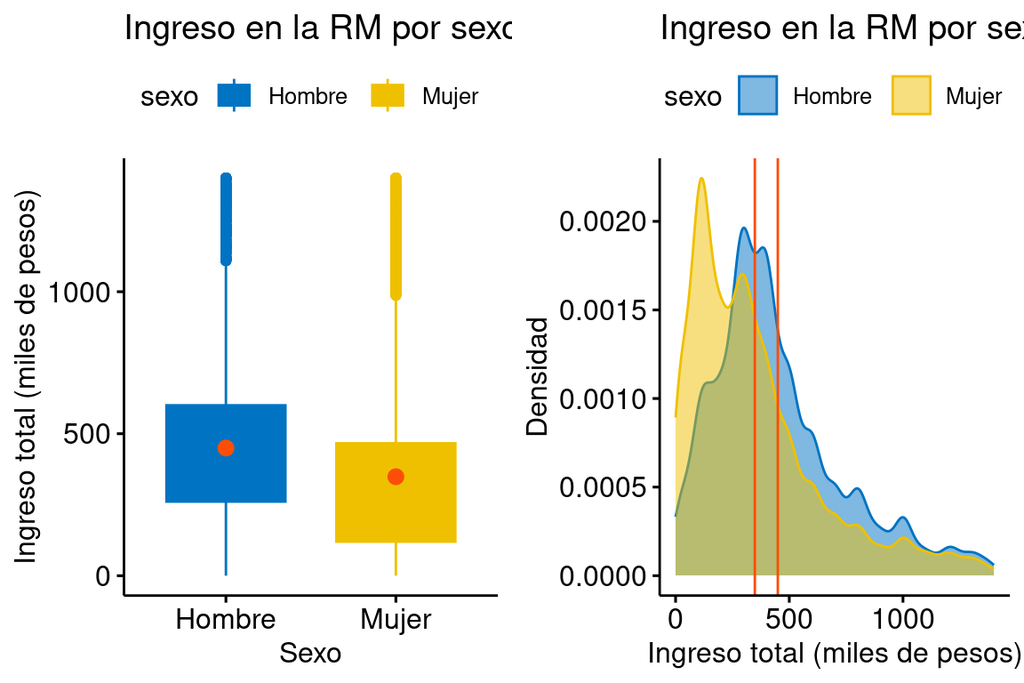

```r
# Diagrama de cajas
g_boxplot3 <- ggboxplot(datos_2, x = "sexo", y = "ytot",
                        color = "sexo", fill = "sexo", palette = "jco",
                        add = "mean", add.params = list(color = "#FC4E07"),
                        title = "Ingreso en la RM por sexo",
                        xlab = "Sexo", ylab = "Ingreso total (miles de pesos)")

# Diagrama de densidad
g_densi3 <- ggdensity(datos_2, x = "ytot",
                      color = "sexo", fill = "sexo", palette = "jco",
                      add = "mean", add.params = list(color = "#FC4E07"),
                      title = "Ingreso en la RM por sexo",
                      xlab = "Ingreso total (miles de pesos)", ylab = "Densidad")

# Juntamos los gráficos
g3 <- ggarrange(g_boxplot3, g_densi3, ncol = 2, nrow = 1)
print(g3)
```

Vemos que se mantiene la asimetría en ambos grupos. Obtengamos las estadísticas descriptivas, teniendo cuidado de no usar las medidas poco robustas (como la media y la desviación estándar).

```r
h <- describe(datos_2[datos_2[["sexo"]] == "Hombre", "ytot"], skew = FALSE, IQR = TRUE, quant = c(0.25, 0.75))
m <- describe(datos_2[datos_2[["sexo"]] == "Mujer", "ytot"], skew = FALSE, IQR = TRUE, quant = c(0.25, 0.75))
estads_3 <- rbind(h, m)
rownames(estads_3) <- c("Hombre", "Mujer")

cat("Estadísticas enfocadas del ingreso por sexo:\n")
print(estads_3)
```

```
Estadísticas enfocadas del ingreso por sexo:
       vars     n   mean     sd median  min  max   range   se    IQR Q0.25
Hombre    1 11079 449.63 289.39 400.00 0.08 1400 1399.92 2.75 339.00   261
Mujer     1 12534 348.53 289.39 282.67 0.08 1400 1399.92 2.58 346.21   120
        Q0.75
Hombre 600.00
Mujer  466.21
```

Podemos concluir.

La fuerte asimetría positiva de los ingresos en Chile se observa en ambos sexos. Sin embargo, las mujeres tienen ingresos algo más bajos que los hombres.

## Análisis de una variable númerica en más de dos grupos distintos

¿Son similares los ingresos registrados en las diferentes provincias de la RM?

El análisis para responder esta pregunta es muy similar al de la pregunta precedente, aunque ahora tenemos una variable categórica con más de dos niveles (más de dos grupos). La construcción del gráfico es idéntica.

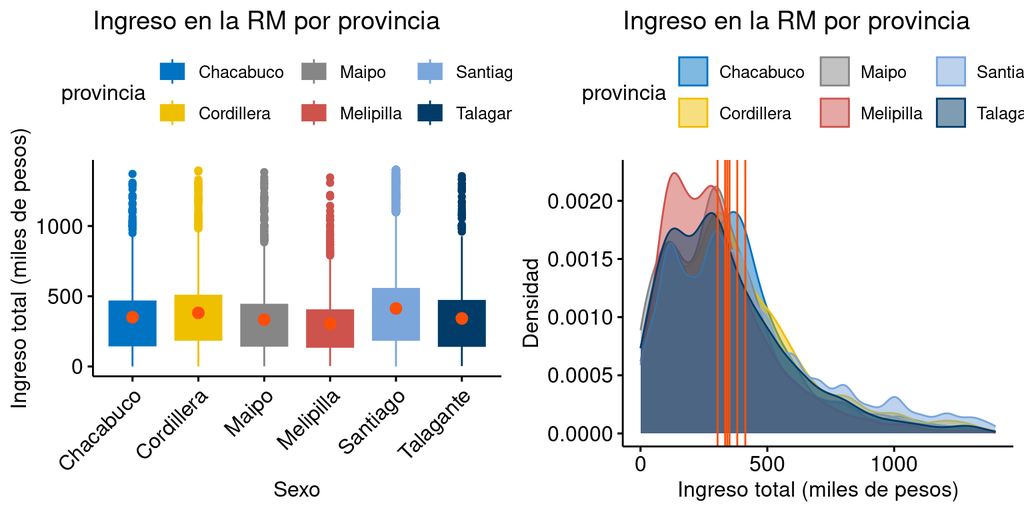

```r
# Diagrama de cajas
g_boxplot4 <- ggboxplot(datos_2, x = "provincia", y = "ytot",
                        color = "provincia", fill = "provincia", palette = "jco",
                        add = "mean", add.params = list(color = "#FC4E07"),
                        title = "Ingreso en la RM por provincia",
                        xlab = "Sexo", ylab = "Ingreso total (miles de pesos)")
g_boxplot4 <- g_boxplot4 + rotate_x_text(angle = 45)

# Diagrama de densidad
g_densi4 <- ggdensity(datos_2, x = "ytot",
                      color = "provincia", fill = "provincia", palette = "jco",
                      add = "mean", add.params = list(color = "#FC4E07"),
                      title = "Ingreso en la RM por provincia",
                      xlab = "Ingreso total (miles de pesos)", ylab = "Densidad")

# Juntamos los gráficos
g4 <- ggarrange(g_boxplot4, g_densi4, ncol = 2, nrow = 1)
print(g4)
```

Lo mismo pasa con las estadísticas descriptivas.

```r
provincias <- levels(datos_2[["provincia"]])
prov1 <- describe(datos_2[datos_2[["provincia"]] == provincias[1], "ytot"], skew = FALSE, IQR = TRUE, quant = c(0.25, 0.75))
prov2 <- describe(datos_2[datos_2[["provincia"]] == provincias[2], "ytot"], skew = FALSE, IQR = TRUE, quant = c(0.25, 0.75))
prov3 <- describe(datos_2[datos_2[["provincia"]] == provincias[3], "ytot"], skew = FALSE, IQR = TRUE, quant = c(0.25, 0.75))
prov4 <- describe(datos_2[datos_2[["provincia"]] == provincias[4], "ytot"], skew = FALSE, IQR = TRUE, quant = c(0.25, 0.75))
prov5 <- describe(datos_2[datos_2[["provincia"]] == provincias[5], "ytot"], skew = FALSE, IQR = TRUE, quant = c(0.25, 0.75))
prov6 <- describe(datos_2[datos_2[["provincia"]] == provincias[6], "ytot"], skew = FALSE, IQR = TRUE, quant = c(0.25, 0.75))
estads_4 <- rbind(prov1, prov2, prov3, prov4, prov5, prov6)
rownames(estads_4) <- provincias

cat("Estadísticas enfocadas del ingreso por provincia:\n")
print(estads_4)
```

```
Estadísticas enfocadas del ingreso por provincia:
           vars     n   mean     sd median  min     max   range   se    IQR
Chacabuco     1  1124 350.97 248.09 322.45 0.83 1370.66 1369.82 7.40 313.12
Cordillera    1  1558 381.53 268.49 326.40 1.00 1395.00 1394.00 6.80 314.58
Maipo         1  1533 333.69 248.83 300.00 1.42 1383.33 1381.92 6.36 291.76
Melipilla     1   867 303.93 217.54 270.00 3.68 1345.59 1341.90 7.39 260.00
Santiago      1 17524 413.23 305.15 350.00 0.08 1400.00 1399.92 2.31 362.92
Talagante     1  1007 342.22 253.35 295.33 2.50 1355.00 1352.50 7.98 320.57
            Q0.25  Q0.75
Chacabuco  150.00 463.12
Cordillera 189.68 504.27
Maipo      148.00 439.76
Melipilla  140.00 400.00
Santiago   189.58 552.50
Talagante  146.52 467.08
```

Hagamos una conclusión con esta información.

Los ingresos de la población adulta de cada provincia de la RM muestra una fuerte asimetría positiva. Si bien no hay grandes diferencias entre ellas, los ingresoslas en las provincias de Talagante y Melipilla se concentran en rangos levemente más bajos (aproximadamente $146 mil a $467 mil y $140 mil a $400 mil, respectivamente), mientras que la provincia de Santiago muestra rangos levemente superiores (de $189 mil a $552 mil aproximadamente).

## Análisis de dos variables númericas

¿Tiene relación el ingreso con la riqueza del municipio donde se habita?

En este caso, queremos ver si una variable numérica **se corelaciona** con otra variable (también numérica). Es decir

- si una variable crece, ¿la otra también?
- o bien, si una variable crece, ¿la otra disminuye?
- o tal vez no hay relación, es decir, las variables **son independientes**.

Una herramienta adecuada para abordar este tipo de preguntas es el **gráfico de dispersión**. Generemos el gráfico para este análisis, nuevamente enfocado en la población adulta con ingresos hasta $1 millón 400 mil (90% de las observaciones).

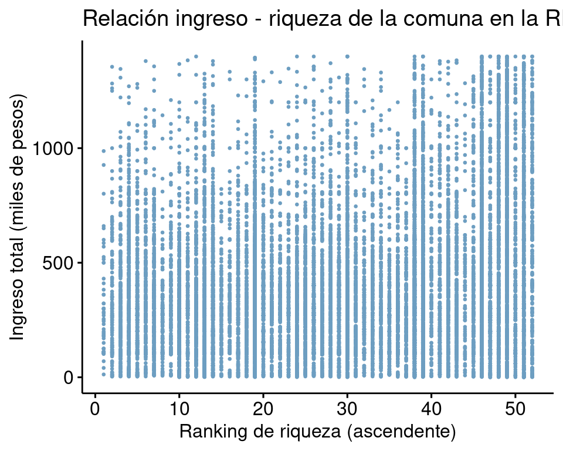

```r
g_disp5 <- ggscatter(datos_2, x = "ing.comuna", y = "ytot",
                    color = "#6D9EC1", fill = "#BFD5E3", size = 0.5,
                    title = "Relación ingreso - riqueza de la comuna en la RM",
                    ylab = "Ingreso total (miles de pesos)",
                    xlab = "Ranking de riqueza (ascendente)")
print(g_disp5)
```

Parece haber un incremento en el número de personas con ingresos altos a medida que aumenta el ranking de la riqueza de la comuna.

En el curso anterior, aprendimos que un estadístico para medir la **fuerza** de la relación entre dos variables numéricas era el **coeficiente de correlación de Pearson**. También vimos que podemos revisar una **línea de regresión** entre las variables. Agreguemos esta información al gráfico.

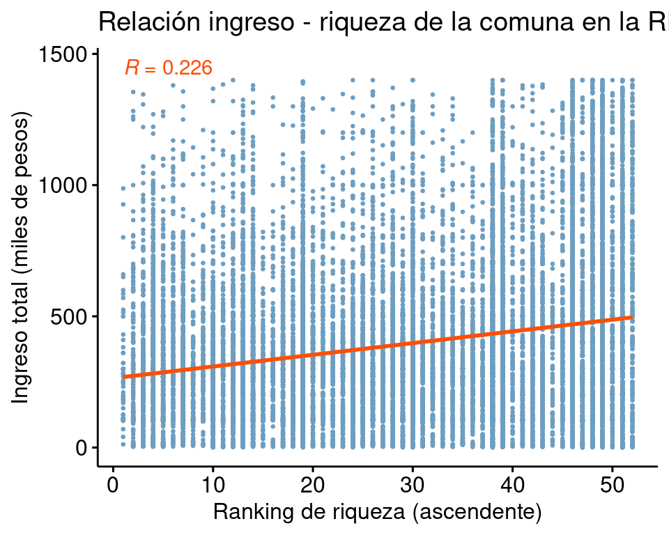

```r
g_disp5 <- g_disp5 + stat_smooth(formula = y ~ x, method = "lm", color = "#FC4E07")
g_disp5 <- g_disp5 + stat_cor(aes(label = after_stat(r.label)), method = "pearson",
                              color = "#FC4E07", r.digits = 3, label.y = 1450)
print(g_disp5)
```

Podemos concluir.

Existe una relación positiva entre el ingreso de las personas y el ranking de riqueza de la comuna, aunque esta es débil ($\small R=0{,}23$).

Nota: debemos mencionar que el coeficiente de correlación de Pearson es una medida **sensible** a valores atípicos o distribuciones asimétricas, por lo que no debería utilizase con estos datos. Se podría usar una alternativa más robusta, como el coeficiente de correlación $\small \rho$ de Spearman (indicando `method = "spearman"` al agregar la estadística al gráfico) o el coeficiente $\small \tau$ de Kendall (con `method = "kendall"`).

## Análisis de dos variables númericas en grupos distintos

¿Van los ingresos de las y los chilenos incrementándose con la experiencia y de forma similar entre hombres y mujeres?

Procedemos en forma similar a la pregunta anterior, pero ahora separamos los diferentes grupos por colores. Construyamos el gráfico, agregando desde un comienzo las líneas de regresión.

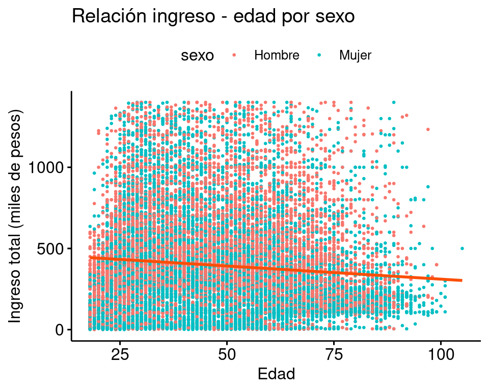

```r
g_disp6 <- ggscatter(datos_2, x = "edad", y = "ytot",
                    color = "sexo", fill = "sexo", size = 0.5,
                    add = "reg.line", add.params = list(color = "#FC4E07"),
                    title = "Relación ingreso - edad por sexo",
                    ylab = "Ingreso total (miles de pesos)",
                    xlab = "Edad")
print(g_disp6)
```

Es difícil ver el gráfico. Parece haber una disminución de los ingresos a medida que se envejece. Pero esta podría ser solo una impresión, puesto que el número de personas encuestadas va disminuyendo con la edad, especialmente después de los 75 años. Para tener una mejor perspectiva, solo consideremos personas menores a la edad de jubilación. Además, separemos por sexo e indiquemos el coeficiente de correlación en cada caso.

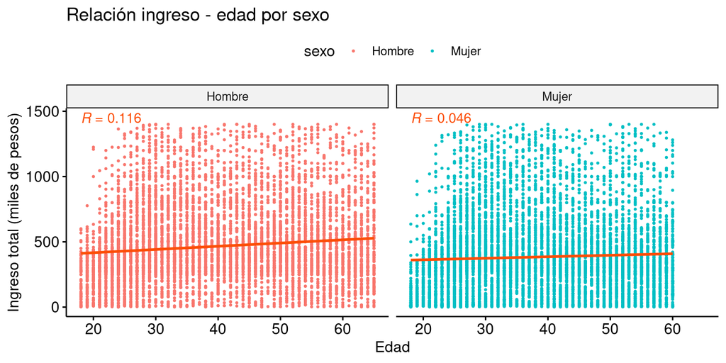

```r
datos_3 <- datos_2 |> filter(sexo == "Hombre" & edad <= 65 | sexo == "Mujer" & edad <= 60) |> droplevels()

g_disp6 <- ggscatter(datos_3, x = "edad", y = "ytot",
                    color = "sexo", fill = "sexo", size = 0.5,
                    add = "reg.line", add.params = list(color = "#FC4E07"),
                    title = "Relación ingreso - edad por sexo",
                    ylab = "Ingreso total (miles de pesos)",
                    xlab = "Edad")
g_disp6 <- g_disp6 + stat_cor(aes(label = after_stat(r.label)), method = "pearson",
                              color = "#FC4E07", r.accuracy = 0.001, label.y = 1450)
g_disp6 <- g_disp6 + facet_wrap(~ sexo)
print(g_disp6)
```

Vemos que la relación cambia completamente (¿caerán los ingresos después de la edad de jubilación?). Saquemos conclusiones con esta información.